# Neural Receiver for SIMO-OFDM Link-Level Simulation

## Summary

This notebook studies a neural receiver for a MIMO-OFDM system using Sionna and PyTorch. The main workflow is:

1. Load libraries and Sionna components.
2. Define simulation parameters, resource grid, antenna setup, and channel configuration.
3. Define the neural receiver architecture using convolutional residual layers.
4. Define the end-to-end communication system, including transmitter, channel, baseline receivers, neural receiver, and decoder.
5. Evaluate baseline receivers using perfect CSI and LS channel estimation.
6. Load and evaluate the pretrained neural receiver.
7. Test neural receiver robustness across different CDL channel models.
8. Test neural receiver robustness under a larger delay spread.
9. Fine-tune the pretrained neural receiver for domain adaptation.
10. Study pruning and INT8 weight round-trip compression for the neural receiver.

The final section is a compression-error experiment. It does not implement true accelerated INT8 inference. Tt evaluates the BLER impact of pruning and quantizing weights for storage, then dequantizing them back into a runnable PyTorch model.

# Step 0: Load libraries and components

General structures are as follow

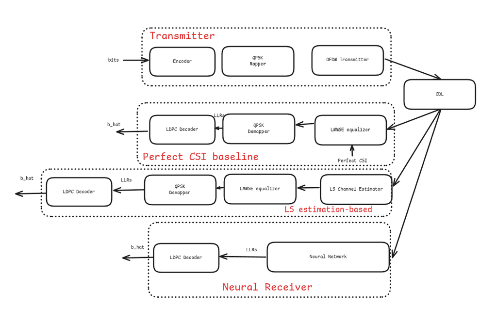

# Step 1: Load Parameters and Initialize Components

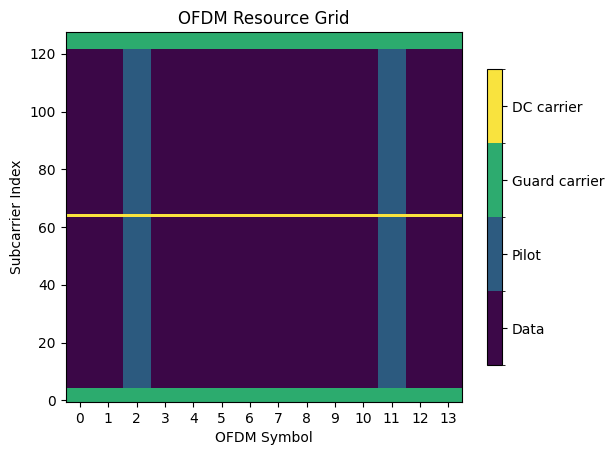

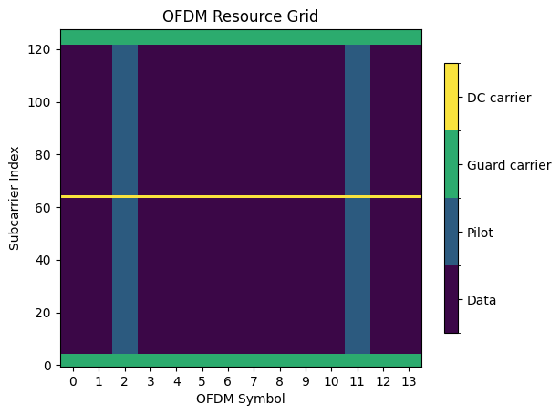

# Step 2: Define the Neural Network

## Overview of the NN

The architecture of the NN is defined as the below diagram

- The complex resource grid is first separated to 5 channels (2 for real, complex values, 2 for 2 antennas, and 1 for noise).
- The input grids are then fed into a convolution to output 128 channels.
- The output is then fed through 4 ResLayer.
- The final output of the neural networks is 2 grids. Each grid holds 1 bit of the estimated symbol at the resource element.

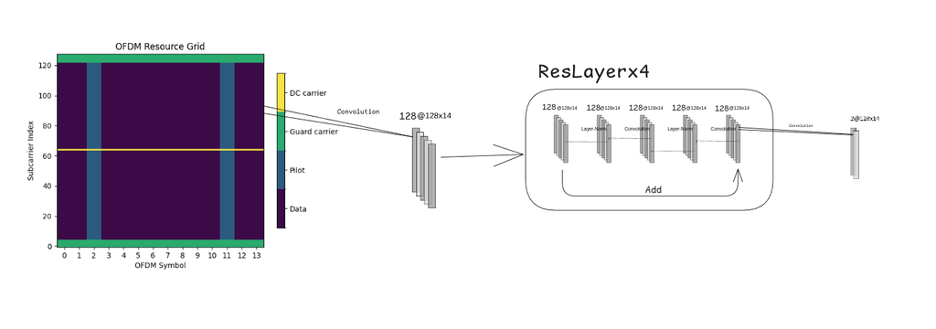

**Why choosing LayerNorm instead of BatchNorm as in normal ResNet**

Because this block wants to normalize each received sample independently, not using statistics from other samples in the mini-batch. This neural receiver is processing a single OFDM resource grid realization per sample.

## Define the Neural Network as the Neural Receiver

## Choose the Optimization Metric

For Binary Classification Problem, BCE loss is the standard. However, to give our loss a meaningful physical meaning, The Bit Metrix Decoding (BMD) rate could be used. The BMD (Bit Metric Decoding) Rate represents the achievable information rate of the system. It tells us that how many information bits can be reliably transmitted per coded bit, given the specific Log-Likelihood Ratios (LLRs) produced by the neural receiver.

PyTorch’s F.binary_cross_entropy_with_logits calculates the loss using the natural logarithm ($\ln$). To convert nats to bits, the BCE must be divided by $\ln(2)$.

For a binary input, the maximum possible information bits per 1 coded bit is 1. To find the achievable information, we subtract the uncertainty (entropy) from the maximum:$$\text{Rate} = 1 - H(B|Y)$$ This becomes:$$\text{Rate} = 1.0 - \frac{\text{BCE Loss}}{\ln(2)}$$

Since BMD rate is just an affine transformation of the BCE rate. Maximizing BCE = Minimizing BCE.

# Step 3: Set up Baseline (LMMSE) and LMMSE with LS estimation

```
EbNo [dB] |        BER |       BLER |  bit errors |    num bits | block errors |  num blocks | runtime [s] |    status
---------------------------------------------------------------------------------------------------------------------------------------
     -5.0 | 2.5239e-01 | 1.0000e+00 |       44969 |      178176 |          128 |         128 |        43.4 |reached target block errors
     -4.5 | 2.3651e-01 | 1.0000e+00 |       42140 |      178176 |          128 |         128 |         0.0 |reached target block errors
     -4.0 | 2.1784e-01 | 1.0000e+00 |       38814 |      178176 |          128 |         128 |         0.0 |reached target block errors
     -3.5 | 1.9617e-01 | 1.0000e+00 |       34953 |      178176 |          128 |         128 |         0.0 |reached target block errors
     -3.0 | 1.6604e-01 | 1.0000e+00 |       29584 |      178176 |          128 |         128 |         0.0 |reached target block errors
     -2.5 | 1.0063e-01 | 9.8438e-01 |       17929 |      178176 |          126 |         128 |         0.0 |reached target block errors
     -2.0 | 1.8813e-02 | 5.2344e-01 |        6704 |      356352 |          134 |         256 |         0.0 |reached target block errors
     -1.5 | 1.2462e-03 | 3.1875e-02 |        5551 |     4454400 |          102 |        3200 |         0.4 |reached target block errors
     -1.0 | 1.5803e-04 | 2.2258e-03 |        9883 |    62539776 |          100 |       44928 |         5.7 |reached target block errors
     -0.5 | 4.5169e-05 | 5.7812e-04 |        8048 |   178176000 |           74 |      128000 |        17.6 |reached max iterations
      0.0 | 1.8560e-05 | 1.7187e-04 |        3307 |   178176000 |           22 |      128000 |        15.8 |reached max iterations
      0.5 | 4.9670e-06 | 8.5937e-05 |         885 |   178176000 |           11 |      128000 |        15.8 |reached max iterations

Simulation stopped as target BLER is reached @ EbNo = 0.5 dB.

EbNo [dB] |        BER |       BLER |  bit errors |    num bits | block errors |  num blocks | runtime [s] |    status
---------------------------------------------------------------------------------------------------------------------------------------
     -5.0 | 3.8919e-01 | 1.0000e+00 |       69344 |      178176 |          128 |         128 |        16.4 |reached target block errors
     -4.5 | 3.8122e-01 | 1.0000e+00 |       67924 |      178176 |          128 |         128 |         0.0 |reached target block errors
     -4.0 | 3.6550e-01 | 1.0000e+00 |       65123 |      178176 |          128 |         128 |         0.0 |reached target block errors
     -3.5 | 3.5699e-01 | 1.0000e+00 |       63607 |      178176 |          128 |         128 |         0.0 |reached target block errors
     -3.0 | 3.3962e-01 | 1.0000e+00 |       60512 |      178176 |          128 |         128 |         0.0 |reached target block errors
     -2.5 | 3.2679e-01 | 1.0000e+00 |       58227 |      178176 |          128 |         128 |         0.0 |reached target block errors
     -2.0 | 3.1082e-01 | 1.0000e+00 |       55381 |      178176 |          128 |         128 |         0.0 |reached target block errors
     -1.5 | 2.9494e-01 | 1.0000e+00 |       52552 |      178176 |          128 |         128 |         0.0 |reached target block errors
     -1.0 | 2.7710e-01 | 1.0000e+00 |       49373 |      178176 |          128 |         128 |         0.0 |reached target block errors
     -0.5 | 2.5574e-01 | 1.0000e+00 |       45567 |      178176 |          128 |         128 |         0.0 |reached target block errors
      0.0 | 2.3130e-01 | 1.0000e+00 |       41212 |      178176 |          128 |         128 |         0.0 |reached target block errors
      0.5 | 2.0710e-01 | 1.0000e+00 |       36900 |      178176 |          128 |         128 |         0.0 |reached target block errors
      1.0 | 1.6576e-01 | 1.0000e+00 |       29535 |      178176 |          128 |         128 |         0.0 |reached target block errors
      1.5 | 7.8793e-02 | 8.8281e-01 |       14039 |      178176 |          113 |         128 |         0.0 |reached target block errors
      2.0 | 1.0419e-02 | 2.3047e-01 |        7426 |      712704 |          118 |         512 |         0.1 |reached target block errors
      2.5 | 7.1106e-04 | 1.0959e-02 |        9122 |    12828672 |          101 |        9216 |         1.2 |reached target block errors
      3.0 | 1.7229e-04 | 1.6242e-03 |       14766 |    85702656 |          100 |       61568 |         7.9 |reached target block errors
      3.5 | 9.9194e-05 | 7.4219e-04 |       17674 |   178176000 |           95 |      128000 |        16.5 |reached max iterations
      4.0 | 4.2290e-05 | 2.9687e-04 |        7535 |   178176000 |           38 |      128000 |        16.7 |reached max iterations
      4.5 | 2.0250e-05 | 1.7187e-04 |        3608 |   178176000 |           22 |      128000 |        16.8 |reached max iterations
      5.0 | 9.8947e-06 | 7.8125e-05 |        1763 |   178176000 |           10 |      128000 |        17.1 |reached max iterations

Simulation stopped as target BLER is reached @ EbNo = 5.0 dB.
```

# Step 4: Training

Training code is kept commented because pretrained weights are used below.

# Evaluation 1: Comparison between the Neural Receivers, LMMSE with perfect CSI, and LMMSE with LS channel estimation

[output not shown]

```
EbNo [dB] |        BER |       BLER |  bit errors |    num bits | block errors |  num blocks | runtime [s] |    status
---------------------------------------------------------------------------------------------------------------------------------------
     -5.0 | 2.5587e-01 | 1.0000e+00 |       45590 |      178176 |          128 |         128 |        12.3 |reached target block errors
     -4.5 | 2.4466e-01 | 1.0000e+00 |       43593 |      178176 |          128 |         128 |         0.1 |reached target block errors
     -4.0 | 2.2220e-01 | 1.0000e+00 |       39590 |      178176 |          128 |         128 |         0.1 |reached target block errors
     -3.5 | 2.0082e-01 | 1.0000e+00 |       35782 |      178176 |          128 |         128 |         0.1 |reached target block errors
     -3.0 | 1.7550e-01 | 1.0000e+00 |       31269 |      178176 |          128 |         128 |         0.1 |reached target block errors
     -2.5 | 1.2250e-01 | 1.0000e+00 |       21826 |      178176 |          128 |         128 |         0.2 |reached target block errors
     -2.0 | 4.2711e-02 | 8.1250e-01 |        7610 |      178176 |          104 |         128 |         0.1 |reached target block errors
     -1.5 | 3.9712e-03 | 1.2612e-01 |        4953 |     1247232 |          113 |         896 |         0.8 |reached target block errors
     -1.0 | 5.5237e-04 | 7.4405e-03 |       10334 |    18708480 |          100 |       13440 |        12.7 |reached target block errors
     -0.5 | 2.7158e-04 | 2.6664e-03 |       14178 |    52205568 |          100 |       37504 |        32.8 |reached target block errors
      0.0 | 1.4552e-04 | 1.1819e-03 |       17138 |   117774336 |          100 |       84608 |       100.6 |reached target block errors
      0.5 | 9.1808e-05 | 7.0312e-04 |       16358 |   178176000 |           90 |      128000 |       107.6 |reached max iterations
      1.0 | 3.9764e-05 | 3.1250e-04 |        7085 |   178176000 |           40 |      128000 |       109.3 |reached max iterations
      1.5 | 3.5757e-05 | 2.5000e-04 |        6371 |   178176000 |           32 |      128000 |       115.4 |reached max iterations
      2.0 | 2.0210e-05 | 1.4062e-04 |        3601 |   178176000 |           18 |      128000 |       113.0 |reached max iterations
      2.5 | 1.0293e-05 | 9.3750e-05 |        1834 |   178176000 |           12 |      128000 |       116.1 |reached max iterations

Simulation stopped as target BLER is reached @ EbNo = 2.5 dB.
```

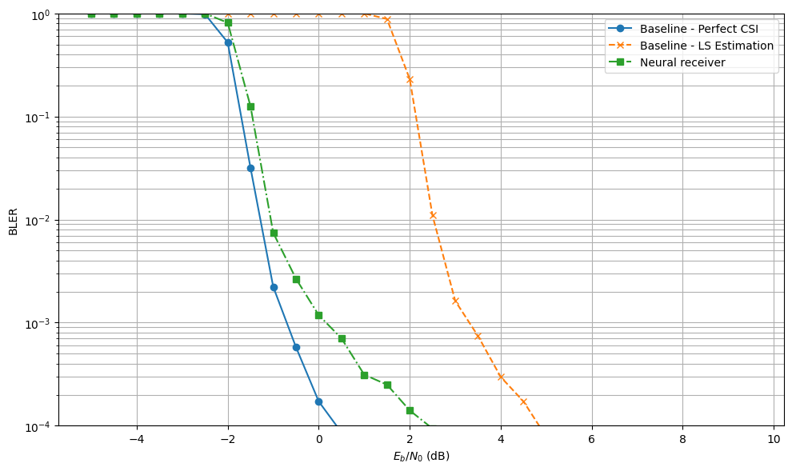

# Evaluation 2: Performance of the Model on different CDL channel model with different conditions

## Different Channel Models

```
EbNo [dB] |        BER |       BLER |  bit errors |    num bits | block errors |  num blocks | runtime [s] |    status
---------------------------------------------------------------------------------------------------------------------------------------
     -5.0 | 2.5700e-01 | 1.0000e+00 |       45791 |      178176 |          128 |         128 |         0.2 |reached target block errors
     -4.5 | 2.4237e-01 | 1.0000e+00 |       43185 |      178176 |          128 |         128 |         0.1 |reached target block errors
     -4.0 | 2.2549e-01 | 1.0000e+00 |       40177 |      178176 |          128 |         128 |         0.1 |reached target block errors
     -3.5 | 2.0490e-01 | 1.0000e+00 |       36508 |      178176 |          128 |         128 |         0.1 |reached target block errors
     -3.0 | 1.7839e-01 | 1.0000e+00 |       31784 |      178176 |          128 |         128 |         0.1 |reached target block errors
     -2.5 | 1.3414e-01 | 1.0000e+00 |       23901 |      178176 |          128 |         128 |         0.1 |reached target block errors
     -2.0 | 4.0031e-02 | 7.7344e-01 |       14265 |      356352 |          198 |         256 |         0.2 |reached target block errors
     -1.5 | 2.4526e-03 | 1.2612e-01 |        3059 |     1247232 |          113 |         896 |         0.8 |reached target block errors
     -1.0 | 2.2102e-04 | 4.1336e-03 |        7443 |    33675264 |          100 |       24192 |        22.5 |reached target block errors
     -0.5 | 9.0218e-05 | 9.4127e-04 |       13342 |   147886080 |          100 |      106240 |        89.5 |reached target block errors
      0.0 | 4.8463e-05 | 4.2187e-04 |        8635 |   178176000 |           54 |      128000 |       108.2 |reached max iterations
      0.5 | 2.2495e-05 | 1.7969e-04 |        4008 |   178176000 |           23 |      128000 |       108.1 |reached max iterations
      1.0 | 4.9838e-06 | 4.6875e-05 |         888 |   178176000 |            6 |      128000 |       111.4 |reached max iterations

Simulation stopped as target BLER is reached @ EbNo = 1.0 dB.

EbNo [dB] |        BER |       BLER |  bit errors |    num bits | block errors |  num blocks | runtime [s] |    status
---------------------------------------------------------------------------------------------------------------------------------------
     -5.0 | 2.7453e-01 | 1.0000e+00 |       48915 |      178176 |          128 |         128 |         0.1 |reached target block errors
     -4.5 | 2.5987e-01 | 1.0000e+00 |       46302 |      178176 |          128 |         128 |         0.1 |reached target block errors
     -4.0 | 2.4925e-01 | 1.0000e+00 |       44411 |      178176 |          128 |         128 |         0.1 |reached target block errors
     -3.5 | 2.2989e-01 | 1.0000e+00 |       40961 |      178176 |          128 |         128 |         0.1 |reached target block errors
     -3.0 | 2.0942e-01 | 1.0000e+00 |       37314 |      178176 |          128 |         128 |         0.1 |reached target block errors
     -2.5 | 1.7728e-01 | 1.0000e+00 |       31587 |      178176 |          128 |         128 |         0.1 |reached target block errors
     -2.0 | 1.3905e-01 | 9.8438e-01 |       24776 |      178176 |          126 |         128 |         0.1 |reached target block errors
     -1.5 | 7.3430e-02 | 6.3281e-01 |       26167 |      356352 |          162 |         256 |         0.2 |reached target block errors
     -1.0 | 3.3360e-02 | 3.2812e-01 |       17832 |      534528 |          126 |         384 |         0.3 |reached target block errors
     -0.5 | 2.2451e-02 | 1.9219e-01 |       20001 |      890880 |          123 |         640 |         0.5 |reached target block errors
      0.0 | 1.1760e-02 | 1.0156e-01 |       16763 |     1425408 |          104 |        1024 |         1.1 |reached target block errors
      0.5 | 6.6590e-03 | 5.2083e-02 |       17797 |     2672640 |          100 |        1920 |         1.9 |reached target block errors
      1.0 | 4.5846e-03 | 3.4986e-02 |       18788 |     4098048 |          103 |        2944 |         2.7 |reached target block errors
      1.5 | 2.8746e-03 | 2.0765e-02 |       19463 |     6770688 |          101 |        4864 |         4.8 |reached target block errors
      2.0 | 2.0070e-03 | 1.3374e-02 |       21098 |    10512384 |          101 |        7552 |         6.3 |reached target block errors
      2.5 | 1.4999e-03 | 9.8892e-03 |       21112 |    14075904 |          100 |       10112 |         8.4 |reached target block errors
      3.0 | 7.9848e-04 | 5.5962e-03 |       20060 |    25122816 |          101 |       18048 |        15.2 |reached target block errors
      3.5 | 5.7446e-04 | 3.6872e-03 |       21904 |    38129664 |          101 |       27392 |        23.6 |reached target block errors
      4.0 | 5.3395e-04 | 3.0518e-03 |       24355 |    45613056 |          100 |       32768 |        30.3 |reached target block errors
      4.5 | 3.6202e-04 | 2.1230e-03 |       23737 |    65568768 |          100 |       47104 |        42.1 |reached target block errors
```

[output cut: 58 more lines]

```
     -4.5 | 2.6197e-01 | 1.0000e+00 |       46676 |      178176 |          128 |         128 |         0.1 |reached target block errors
     -4.0 | 2.4668e-01 | 1.0000e+00 |       43953 |      178176 |          128 |         128 |         0.1 |reached target block errors
     -3.5 | 2.3225e-01 | 1.0000e+00 |       41382 |      178176 |          128 |         128 |         0.1 |reached target block errors
     -3.0 | 2.0753e-01 | 1.0000e+00 |       36976 |      178176 |          128 |         128 |         0.1 |reached target block errors
     -2.5 | 1.8691e-01 | 1.0000e+00 |       33303 |      178176 |          128 |         128 |         0.1 |reached target block errors
     -2.0 | 1.4556e-01 | 1.0000e+00 |       25935 |      178176 |          128 |         128 |         0.1 |reached target block errors
     -1.5 | 9.0888e-02 | 8.9844e-01 |       16194 |      178176 |          115 |         128 |         0.1 |reached target block errors
     -1.0 | 3.1474e-02 | 4.4141e-01 |       11216 |      356352 |          113 |         256 |         0.2 |reached target block errors
     -0.5 | 8.6721e-03 | 1.3021e-01 |        9271 |     1069056 |          100 |         768 |         0.7 |reached target block errors
      0.0 | 1.8678e-03 | 3.1563e-02 |        8320 |     4454400 |          101 |        3200 |         2.8 |reached target block errors
      0.5 | 1.9426e-04 | 4.3890e-03 |        6161 |    31715328 |          100 |       22784 |        22.1 |reached target block errors
      1.0 | 3.7805e-05 | 6.0937e-04 |        6736 |   178176000 |           78 |      128000 |       111.4 |reached max iterations
      1.5 | 6.4936e-06 | 7.0312e-05 |        1157 |   178176000 |            9 |      128000 |       108.7 |reached max iterations

Simulation stopped as target BLER is reached @ EbNo = 1.5 dB.
```

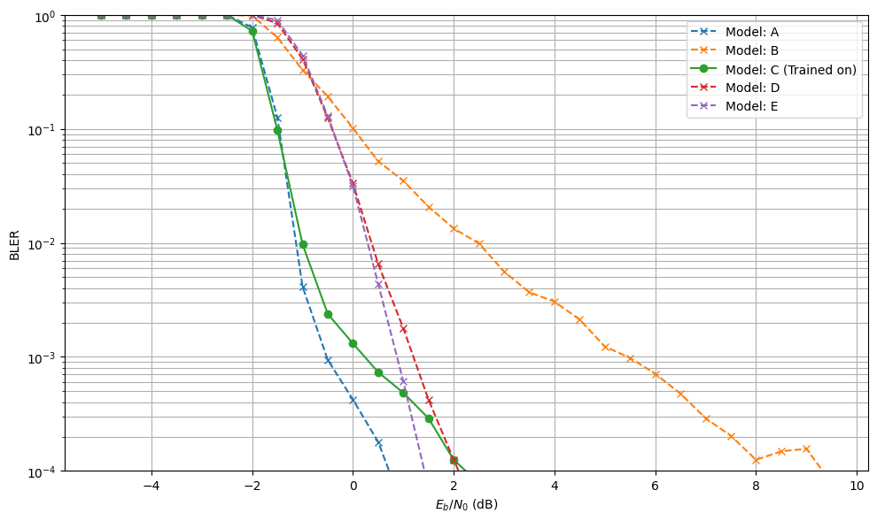

The receiver generalizes almost perfectly across model C, D and E. It also performs slightly better on A-model. B-model is the only model that the receiver cannot generalize.

We can observe that across all standard 3GPP CDL channel models, the neural receiver maintains a maximum performance degradation of exactly 3.5 dB at a target BLER of $\approx 10^{-2}$.

To create a truly robust neural receiver, we can randomly feed the network with a randomized mix of difference channel models.

# Different Delay Spread

```
EbNo [dB] |        BER |       BLER |  bit errors |    num bits | block errors |  num blocks | runtime [s] |    status
---------------------------------------------------------------------------------------------------------------------------------------
     -5.0 | 3.2008e-01 | 1.0000e+00 |       57030 |      178176 |          128 |         128 |         0.1 |reached target block errors
     -4.5 | 3.0483e-01 | 1.0000e+00 |       54313 |      178176 |          128 |         128 |         0.1 |reached target block errors
     -4.0 | 2.9227e-01 | 1.0000e+00 |       52075 |      178176 |          128 |         128 |         0.1 |reached target block errors
     -3.5 | 2.8378e-01 | 1.0000e+00 |       50563 |      178176 |          128 |         128 |         0.1 |reached target block errors
     -3.0 | 2.6252e-01 | 1.0000e+00 |       46775 |      178176 |          128 |         128 |         0.1 |reached target block errors
     -2.5 | 2.4452e-01 | 1.0000e+00 |       43567 |      178176 |          128 |         128 |         0.1 |reached target block errors
     -2.0 | 2.2703e-01 | 1.0000e+00 |       40452 |      178176 |          128 |         128 |         0.1 |reached target block errors
     -1.5 | 2.1200e-01 | 1.0000e+00 |       37773 |      178176 |          128 |         128 |         0.1 |reached target block errors
     -1.0 | 1.8756e-01 | 1.0000e+00 |       33419 |      178176 |          128 |         128 |         0.1 |reached target block errors
     -0.5 | 1.3108e-01 | 8.6719e-01 |       23356 |      178176 |          111 |         128 |         0.1 |reached target block errors
      0.0 | 1.0272e-01 | 7.9297e-01 |       36603 |      356352 |          203 |         256 |         0.2 |reached target block errors
      0.5 | 5.1749e-02 | 5.0391e-01 |       18441 |      356352 |          129 |         256 |         0.2 |reached target block errors
      1.0 | 3.7723e-02 | 2.8906e-01 |       20164 |      534528 |          111 |         384 |         0.3 |reached target block errors
      1.5 | 1.4732e-02 | 1.4583e-01 |       15749 |     1069056 |          112 |         768 |         0.7 |reached target block errors
      2.0 | 9.4957e-03 | 8.3594e-02 |       16919 |     1781760 |          107 |        1280 |         1.1 |reached target block errors
      2.5 | 5.9860e-03 | 4.3837e-02 |       19198 |     3207168 |          101 |        2304 |         2.2 |reached target block errors
      3.0 | 3.4906e-03 | 2.4148e-02 |       20524 |     5879808 |          102 |        4224 |         3.6 |reached target block errors
      3.5 | 2.1496e-03 | 1.5625e-02 |       19916 |     9265152 |          104 |        6656 |         5.9 |reached target block errors
      4.0 | 2.1617e-03 | 1.2620e-02 |       25036 |    11581440 |          105 |        8320 |         7.5 |reached target block errors
      4.5 | 1.5820e-03 | 9.3006e-03 |       23677 |    14966784 |          100 |       10752 |         9.1 |reached target block errors
      5.0 | 9.5178e-04 | 5.5568e-03 |       24081 |    25300992 |          101 |       18176 |        15.5 |reached target block errors
      5.5 | 8.6300e-04 | 4.6781e-03 |       25679 |    29755392 |          100 |       21376 |        18.8 |reached target block errors
      6.0 | 7.3329e-04 | 3.9062e-03 |       26131 |    35635200 |          100 |       25600 |        22.4 |reached target block errors
      6.5 | 6.7584e-04 | 3.3675e-03 |       27937 |    41336832 |          100 |       29696 |        26.0 |reached target block errors
      7.0 | 4.3403e-04 | 2.2911e-03 |       26371 |    60758016 |          100 |       43648 |        38.4 |reached target block errors
      7.5 | 3.7102e-04 | 2.0398e-03 |       25319 |    68241408 |          100 |       49024 |        41.7 |reached target block errors
      8.0 | 3.2086e-04 | 1.6729e-03 |       26698 |    83208192 |          100 |       59776 |        51.7 |reached target block errors
      8.5 | 3.0469e-04 | 1.6552e-03 |       25624 |    84099072 |          100 |       60416 |        61.0 |reached target block errors
      9.0 | 2.1983e-04 | 1.2169e-03 |       25146 |   114388992 |          100 |       82176 |        68.7 |reached target block errors
      9.5 | 1.8718e-04 | 1.0459e-03 |       24913 |   133097472 |          100 |       95616 |        79.9 |reached target block errors
```

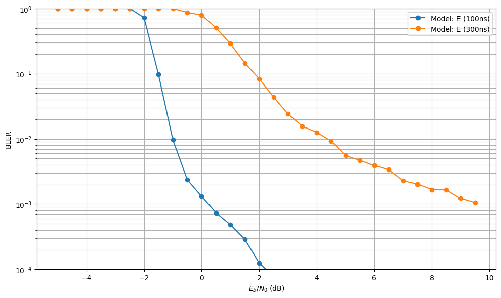

We can observe that the receiver performs much worse in high-delay spread just as in traditional receivers.

# Step 5: Finetune the pretrained Neural Receiver

```
Baseline BLER at 2.5dB: 0.00989
Step   50 | Loss: -0.8113 | BLER: 0.03250 | Gain: -0.02261
Step  100 | Loss: -0.8449 | BLER: 0.02078 | Gain: -0.01089
Step  150 | Loss: -0.5486 | BLER: 0.01773 | Gain: -0.00785
Step  200 | Loss: -0.4659 | BLER: 0.01781 | Gain: -0.00792
Step  250 | Loss: -0.9713 | BLER: 0.01320 | Gain: -0.00331
Step  300 | Loss: -0.5770 | BLER: 0.01180 | Gain: -0.00191
Step  350 | Loss: -0.9494 | BLER: 0.00781 | Gain: 0.00208
Step  400 | Loss: -0.9688 | BLER: 0.00758 | Gain: 0.00231
Step  450 | Loss: -0.6826 | BLER: 0.00711 | Gain: 0.00278
Step  500 | Loss: -0.7669 | BLER: 0.00586 | Gain: 0.00403
Step  550 | Loss: -0.3438 | BLER: 0.00445 | Gain: 0.00544
Step  600 | Loss: -0.5810 | BLER: 0.00500 | Gain: 0.00489
Step  650 | Loss: -0.9839 | BLER: 0.00500 | Gain: 0.00489
Step  700 | Loss: -0.9635 | BLER: 0.00359 | Gain: 0.00630
Step  750 | Loss: -0.9573 | BLER: 0.00422 | Gain: 0.00567
Step  800 | Loss: -0.5893 | BLER: 0.00344 | Gain: 0.00645
Step  850 | Loss: -0.7840 | BLER: 0.00336 | Gain: 0.00653
Step  900 | Loss: -0.9233 | BLER: 0.00289 | Gain: 0.00700
Step  950 | Loss: -0.7570 | BLER: 0.00250 | Gain: 0.00739
Step 1000 | Loss: -0.9828 | BLER: 0.00398 | Gain: 0.00590
```

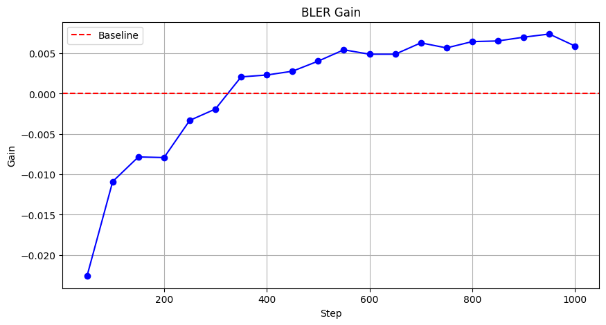

A full SNR sweep can be implemented next to verify the gain across the entire waterfall curve.

# Step 6: Quantization and Pruning

Changing FP32 to INT8 is not just `model.to(torch.int8)`. PyTorch convolution layers normally expect floating-point inputs and floating-point weights. Real INT8 inference needs a new modified model that knows how to run INT8 convolution kernels.

Therefore, the following experiment studies only weight compression error, not accelerated INT8 inference.

```
FP32 model loaded
Output shape: (2, 14, 128, 2)
Original FP32 checkpoint size: 18.55 MiB
```

```
Pruned Conv2d layers: 10
Zero parameters: 7.59%
MSE difference from FP32 output: 9.3917e+00
Saved dense pruned model to: neural_receiver_weights_pruned
```

```
MSE difference from pruned output: 4.0656e-02
Saved runnable dequantized model to: neural_receiver_weights_pruned_dequantized_from_int8
Runnable dequantized model size: 18.55 MiB
Saved real INT8 weight-storage file to: neural_receiver_weights_int8_weights_only
INT8 weight-storage file size: 9.90 MiB
```

```
EbNo [dB] |        BER |       BLER |  bit errors |    num bits | block errors |  num blocks | runtime [s] |    status
---------------------------------------------------------------------------------------------------------------------------------------
     -5.0 | 2.8620e-01 | 1.0000e+00 |       50994 |      178176 |          128 |         128 |         0.2 |reached target block errors
     -4.5 | 2.7226e-01 | 1.0000e+00 |       48511 |      178176 |          128 |         128 |         0.2 |reached target block errors
     -4.0 | 2.5033e-01 | 1.0000e+00 |       44603 |      178176 |          128 |         128 |         0.1 |reached target block errors
     -3.5 | 2.3281e-01 | 1.0000e+00 |       41482 |      178176 |          128 |         128 |         0.1 |reached target block errors
     -3.0 | 2.1031e-01 | 1.0000e+00 |       37473 |      178176 |          128 |         128 |         0.1 |reached target block errors
     -2.5 | 1.8441e-01 | 1.0000e+00 |       32857 |      178176 |          128 |         128 |         0.1 |reached target block errors
     -2.0 | 1.5606e-01 | 1.0000e+00 |       27806 |      178176 |          128 |         128 |         0.1 |reached target block errors
     -1.5 | 9.0371e-02 | 9.9219e-01 |       16102 |      178176 |          127 |         128 |         0.1 |reached target block errors
     -1.0 | 8.6937e-03 | 2.5977e-01 |        6196 |      712704 |          133 |         512 |         0.6 |reached target block errors
     -0.5 | 7.7131e-04 | 1.1496e-02 |        9620 |    12472320 |          103 |        8960 |         8.0 |reached target block errors
      0.0 | 3.1976e-04 | 3.4011e-03 |       13218 |    41336832 |          101 |       29696 |        25.3 |reached target block errors
      0.5 | 1.3835e-04 | 1.2585e-03 |       15456 |   111716352 |          101 |       80256 |        71.9 |reached target block errors
      1.0 | 7.2378e-05 | 6.0156e-04 |       12896 |   178176000 |           77 |      128000 |       115.8 |reached max iterations
      1.5 | 3.6296e-05 | 3.2813e-04 |        6467 |   178176000 |           42 |      128000 |       160.1 |reached max iterations
      2.0 | 2.6103e-05 | 2.0312e-04 |        4651 |   178176000 |           26 |      128000 |       118.0 |reached max iterations
      2.5 | 3.0021e-05 | 2.0312e-04 |        5349 |   178176000 |           26 |      128000 |       118.8 |reached max iterations
      3.0 | 1.2796e-05 | 7.8125e-05 |        2280 |   178176000 |           10 |      128000 |       110.4 |reached max iterations

Simulation stopped as target BLER is reached @ EbNo = 3.0 dB.
```

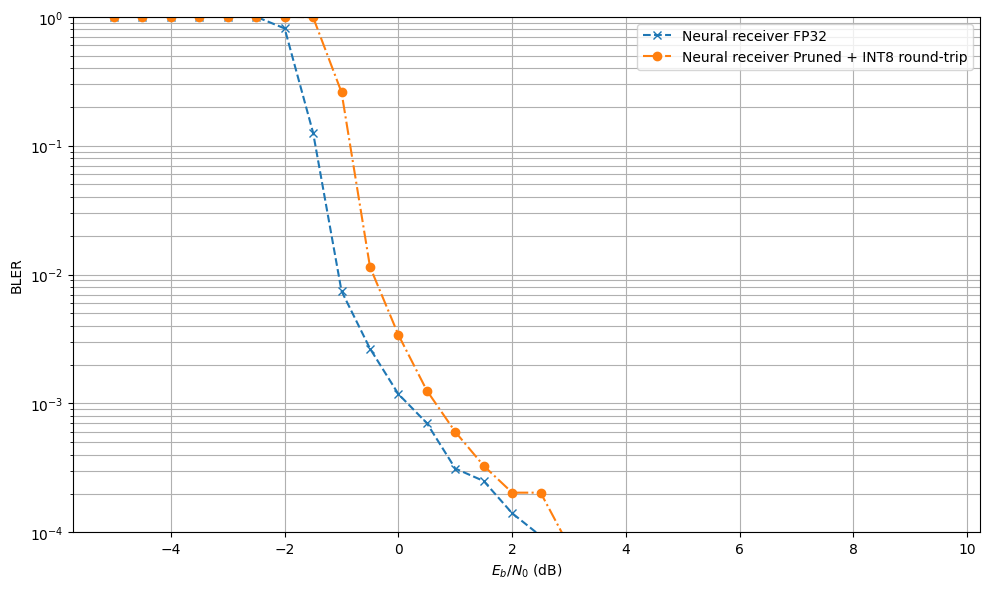

Pruning and quantization do not appear to significantly degrade the BLER performance. The main observable impact is a relatively small loss of about 0.5 dB at a BLER of $10^{-3}$, which suggests that the compressed model still preserves most of the original performance. However, as stated above, this is a compression-error study, not a true INT8 inference benchmark.